# Biostat 203B Homework 5

Due Mar 22 @ 11:59PM

Author

Name: Hiroyasu Ando, UID: 605948443

Display machine information:

Display my machine memory.

```r
memuse::Sys.meminfo()
```

```
Totalram:   16.000 GiB
Freeram:   841.172 MiB
```

Load database libraries and the tidyverse frontend:

```r
library(GGally)
library(dbplyr)
library(tidyverse)
library(gtsummary)
library(tidymodels)
library(stacks)
```

## Predicting ICU duration

Using the ICU cohort `mimiciv_icu_cohort.rds` you built in Homework 4, develop at least three machine learning approaches (logistic regression with enet regularization, random forest, boosting, SVM, MLP, etc) plus a model stacking approach for predicting whether a patient’s ICU stay will be longer than 2 days. You should use the `los_long` variable as the outcome. You algorithms can use patient demographic information (gender, age at ICU `intime`, marital status, race), ICU admission information (first care unit), the last lab measurements before the ICU stay, and first vital measurements during ICU stay as features. You are welcome to use any feature engineering techniques you think are appropriate; but make sure to not use features that are not available at an ICU stay’s `intime`. For instance, `last_careunit` cannot be used in your algorithms.

1. Data preprocessing and feature engineering.

```r
mimic_icu_cohort_raw <- readRDS("../hw4/mimiciv_shiny/mimic_icu_cohort.rds")

mimic_icu_cohort_pre <- mimic_icu_cohort_raw |>
  mutate(
    first_careunit = fct_lump(first_careunit, n = 4),
    los_long = if_else(los >= 2, as.factor(1), as.factor(0)),
    race = fct_collapse(
      race,
      ASIAN = mimic_icu_cohort_raw$race[str_detect(mimic_icu_cohort_raw$race,
                                                   "ASIAN")],
      WHITE = mimic_icu_cohort_raw$race[str_detect(mimic_icu_cohort_raw$race,
                                                   "WHITE")],
      BLACK = mimic_icu_cohort_raw$race[str_detect(mimic_icu_cohort_raw$race,
                                                   "BLACK")],
      HISPANIC = mimic_icu_cohort_raw$race[str_detect(mimic_icu_cohort_raw$race,
                                                      "HISPANIC")],
      other_level = "Other")) |>
  select(gender, age_intime, marital_status, race, first_careunit,
         los_long, sodium, chloride,
         creatinine, potassium, glucose, hematocrit, wbc, bicarbonate,
         temperature_fahrenheit, non_invasive_blood_pressure_diastolic,
         respiratory_rate, non_invasive_blood_pressure_systolic, heart_rate,
         subject_id, hadm_id, stay_id)
```

```r
mimic_icu_cohort_pre |>
  select(- subject_id, - hadm_id, - stay_id) |>
  tbl_summary(by = los_long)
```

| **Characteristic** | **1**, N = 35,131<sup>1</sup> | **0**, N = 38,050<sup>1</sup> |
| --- | --- | --- |
| gender |  |  |
| F | 15,349 (44%) | 17,014 (45%) |
| M | 19,782 (56%) | 21,036 (55%) |
| age_intime | 67 (56, 78) | 65 (53, 77) |
| marital_status |  |  |
| DIVORCED | 2,561 (7.9%) | 2,843 (8.0%) |
| MARRIED | 15,784 (49%) | 16,984 (48%) |
| SINGLE | 9,683 (30%) | 11,175 (31%) |
| WIDOWED | 4,339 (13%) | 4,699 (13%) |
| Unknown | 2,764 | 2,349 |
| race |  |  |
| ASIAN | 1,007 (2.9%) | 1,148 (3.0%) |
| BLACK | 3,649 (10%) | 4,311 (11%) |
| HISPANIC | 1,249 (3.6%) | 1,492 (3.9%) |
| WHITE | 23,630 (67%) | 25,939 (68%) |
| Other | 5,596 (16%) | 5,160 (14%) |
| first_careunit |  |  |
| Cardiac Vascular Intensive Care Unit (CVICU) | 5,755 (16%) | 5,827 (15%) |
| Medical Intensive Care Unit (MICU) | 7,116 (20%) | 8,782 (23%) |
| Medical/Surgical Intensive Care Unit (MICU/SICU) | 5,586 (16%) | 7,147 (19%) |
| Surgical Intensive Care Unit (SICU) | 5,507 (16%) | 5,654 (15%) |
| Other | 11,167 (32%) | 10,640 (28%) |
| sodium | 138.0 (135.0, 141.0) | 139.0 (136.0, 141.0) |
| Unknown | 4,698 | 4,174 |
| chloride | 102 (98, 105) | 102 (98, 105) |
| Unknown | 4,708 | 4,175 |
| creatinine | 1.00 (0.80, 1.60) | 1.00 (0.80, 1.40) |
| Unknown | 3,171 | 2,599 |
| potassium | 4.20 (3.80, 4.70) | 4.20 (3.80, 4.60) |
| Unknown | 4,712 | 4,189 |
| glucose | 122 (100, 159) | 118 (98, 153) |
| Unknown | 4,817 | 4,282 |
| hematocrit | 35 (29, 40) | 36 (30, 40) |
| Unknown | 2,781 | 2,236 |
| wbc | 9.7 (7.0, 13.8) | 9.0 (6.6, 12.6) |
| Unknown | 2,822 | 2,272 |
| bicarbonate | 24.0 (21.0, 27.0) | 25.0 (22.0, 27.0) |
| Unknown | 4,780 | 4,270 |
| temperature_fahrenheit | 98.20 (97.60, 98.80) | 98.10 (97.60, 98.60) |
| Unknown | 173 | 1,189 |
| non_invasive_blood_pressure_diastolic | 66 (55, 79) | 68 (58, 80) |
| Unknown | 250 | 733 |
| respiratory_rate | 19.0 (15.0, 23.0) | 18.0 (15.0, 22.0) |
| Unknown | 11 | 87 |
| non_invasive_blood_pressure_systolic | 120 (104, 138) | 122 (107, 139) |
| Unknown | 247 | 732 |
| heart_rate | 88 (76, 103) | 85 (74, 99) |
| Unknown | 1 | 17 |

<sup>1</sup> n (%); Median (IQR)

2. Partition data into 50% training set and 50% test set. Stratify partitioning according to `los_long`. For grading purpose, sort the data by `subject_id`, `hadm_id`, and `stay_id` and use the seed `203` for the initial data split. Below is the sample code.

```r
set.seed(203)

mimiciv_icu_cohort <- mimic_icu_cohort_pre |>
  arrange(subject_id, hadm_id, stay_id)

data_split <- initial_split(
  mimiciv_icu_cohort,
  strata = "los_long",
  prop = 0.5)

mimiciv_icu_cohort_other <- training(data_split)
mimiciv_icu_cohort_test <- testing(data_split)
```

3. Train and tune the models using the training set.

```r
# Make the general recepe and folds for the models.

mimic_icu_cohort_recipe <-
  recipe(
    los_long ~ .,
    data = mimiciv_icu_cohort_other
    ) |>
  step_rm(subject_id, hadm_id, stay_id) |>
  step_impute_mode(marital_status) |>
  step_impute_mean(sodium) |>
  step_impute_mean(chloride) |>
  step_impute_median(creatinine) |>
  step_impute_mean(potassium) |>
  step_impute_median(glucose) |>
  step_impute_mean(hematocrit) |>
  step_impute_median(wbc) |>
  step_impute_mean(bicarbonate) |>
  step_impute_median(temperature_fahrenheit) |>
  step_impute_median(non_invasive_blood_pressure_diastolic) |>
  step_impute_median(respiratory_rate) |>
  step_impute_median(non_invasive_blood_pressure_systolic) |>
  step_impute_median(heart_rate) |>
  step_dummy(all_nominal_predictors()) |>
  step_normalize(all_numeric_predictors()) |>
  step_zv(all_numeric_predictors())

folds <- vfold_cv(mimiciv_icu_cohort_other, v = 5)
```

**Logsitic regression:**

```r
logit_mod <-
  logistic_reg(
    penalty = tune(),
    mixture = tune()
    ) |>
  set_engine("glmnet", standardize = TRUE)

logit_wf <- workflow() |>
  add_recipe(mimic_icu_cohort_recipe) |>
  add_model(logit_mod)

logit_param_grid <- grid_regular(
  penalty(range = c(-3, -1)),
  mixture(),
  levels = c(5, 2))

logit_fit <- logit_wf |>
  tune_grid(
    resamples = folds,
    grid = logit_param_grid,
    metrics = metric_set(roc_auc, accuracy))

best_logit <- logit_fit |>
  select_best("roc_auc")

logit_final_wf <- logit_wf |>
  finalize_workflow(best_logit)

logit_final_fit <-
  logit_final_wf |>
  last_fit(data_split)
```

**Random forest:**

```r
rf_mod <-
  rand_forest(
    mode = "classification",
    mtry = tune(),
    trees = tune()
    ) |>
  set_engine("ranger", importance = "impurity")

rf_wf <- workflow() |>
  add_recipe(mimic_icu_cohort_recipe) |>
  add_model(rf_mod)

rf_param_grid <- grid_regular(
  trees(range = c(10L, 25L)),
  mtry(range = c(1L, 2L)),
  levels = c(4, 2))

rf_fit <- rf_wf |>
  tune_grid(
    resamples = folds,
    grid = rf_param_grid,
    metrics = metric_set(roc_auc, accuracy))

best_rf <- rf_fit |>
  select_best("roc_auc")

rf_final_wf <- rf_wf |>
  finalize_workflow(best_rf)

rf_final_fit <-
  rf_final_wf |>
  last_fit(data_split)
```

**XGBoost:**

```r
gb_mod <-
  boost_tree(
    mode = "classification",
    trees = 100,
    tree_depth = tune(),
    learn_rate = tune()
    ) |>
  set_engine("xgboost")

gb_wf <- workflow() |>
  add_recipe(mimic_icu_cohort_recipe) |>
  add_model(gb_mod)

gb_param_grid <- grid_regular(
  tree_depth(range = c(1L, 2L)),
  learn_rate(range = c(-2, 1), trans = log10_trans()),
  levels = c(3, 3))

gb_fit <- gb_wf |>
  tune_grid(
    resamples = folds,
    grid = gb_param_grid,
    metrics = metric_set(roc_auc, accuracy))

best_gb <- gb_fit |>
  select_best("roc_auc")

gb_final_wf <- gb_wf |>
  finalize_workflow(best_gb)

gb_final_fit <-
  gb_final_wf |>
  last_fit(data_split)
```

4. Compare model classification performance on the test set. Report both the area under ROC curve and accuracy for each machine learning algorithm and the model stacking. Interpret the results. What are the most important features in predicting long ICU stays? How do the models compare in terms of performance and interpretability?

**ROC curve and accuracy for the three models**

```r
# Logsitic regression
# Accuracy: ~ 0.573
# AUC: ~ 0.594

logit_final_fit |>
  collect_metrics()
```

```
# A tibble: 2 × 4
  .metric  .estimator .estimate .config
  <chr>    <chr>          <dbl> <chr>
1 accuracy binary         0.573 Preprocessor1_Model1
2 roc_auc  binary         0.594 Preprocessor1_Model1
```

```r
# Random forest
# Accuracy: ~ 0.579
# AUC: ~ 0.609

rf_final_fit |>
  collect_metrics()
```

```
# A tibble: 2 × 4
  .metric  .estimator .estimate .config
  <chr>    <chr>          <dbl> <chr>
1 accuracy binary         0.579 Preprocessor1_Model1
2 roc_auc  binary         0.609 Preprocessor1_Model1
```

```r
# XGBoost
# Accuracy: ~ 0.593
# AUC: ~ 0.631

gb_final_fit |>
  collect_metrics()
```

```
# A tibble: 2 × 4
  .metric  .estimator .estimate .config
  <chr>    <chr>          <dbl> <chr>
1 accuracy binary         0.593 Preprocessor1_Model1
2 roc_auc  binary         0.631 Preprocessor1_Model1
```

**ROC curve and accuracy for the stacking model**

```r
# Stacking model
# Accuracy: ~ 0.595
# AUC: 0.634

logit_res <-
  tune_grid(
    object = logit_wf,
    resamples = folds,
    grid = logit_param_grid,
    control = control_stack_grid())

rf_res <-
  tune_grid(
    object = rf_wf,
    resamples = folds,
    grid = rf_param_grid,
    control = control_stack_grid())

gb_res <-
  tune_grid(
    object = gb_wf,
    resamples = folds,
    grid = gb_param_grid,
    control = control_stack_grid())

mimiciv_icu_cohort_model_st <-
  stacks() |>
  add_candidates(logit_res) |>
  add_candidates(rf_res) |>
  add_candidates(gb_res) |>
  blend_predictions(
    penalty = 10^(-6:2),
    metrics = c("roc_auc")) |>
  fit_members()

mimiciv_icu_cohort_pred <- mimiciv_icu_cohort_test %>%
  bind_cols(predict(mimiciv_icu_cohort_model_st, ., type = "prob"))

mimiciv_icu_cohort_pred <- mimiciv_icu_cohort_pred |>
  mutate(est = fct_relevel(as.factor(if_else(.pred_1 >= 0.5, 1, 0)), "1", "0"))

yardstick::roc_auc(
  mimiciv_icu_cohort_pred,
  truth = los_long,
  contains(".pred_1"))
```

```
# A tibble: 1 × 3
  .metric .estimator .estimate
  <chr>   <chr>          <dbl>
1 roc_auc binary         0.634
```

```r
yardstick::accuracy(
  mimiciv_icu_cohort_pred,
  truth = los_long,
  estimate = est)
```

```
# A tibble: 1 × 3
  .metric  .estimator .estimate
  <chr>    <chr>          <dbl>
1 accuracy binary         0.595
```

**Interpretation**

The stacking model has the best performance in terms of accuracy and AUC, followed by the xgboost, random forest, and logistic models.

For each model, the most important features in predicting long ICU stays are as follows:

Logistic regression : Whether patients have “Medical/Surgical Intensive Care Unit (MICU/SICU)” as their first care unite.

Random forest : “hematocrit” before the ICU stay

XGBoost : First “temperature fahrenheit” during ICU stay

```r
# Logistic regression
logit_final_fit |> extract_fit_engine() |> vip::vi()
```

```
# A tibble: 26 × 3
   Variable                                                     Importance Sign
   <chr>                                                             <dbl> <chr>
 1 first_careunit_Medical.Surgical.Intensive.Care.Unit..MICU.S…     0.179  POS
 2 first_careunit_Medical.Intensive.Care.Unit..MICU.                0.172  POS
 3 heart_rate                                                       0.167  NEG
 4 hematocrit                                                       0.127  POS
 5 age_intime                                                       0.118  NEG
 6 respiratory_rate                                                 0.113  NEG
 7 chloride                                                         0.105  POS
 8 wbc                                                              0.103  NEG
 9 non_invasive_blood_pressure_systolic                             0.0905 POS
10 sodium                                                           0.0844 NEG
# ℹ 16 more rows
```

```r
# Random forest
rf_final_fit |> extract_fit_engine() |> vip::vi()
```

```
# A tibble: 26 × 2
   Variable                              Importance
   <chr>                                      <dbl>
 1 hematocrit                                  651.
 2 non_invasive_blood_pressure_systolic        642.
 3 heart_rate                                  641.
 4 wbc                                         636.
 5 temperature_fahrenheit                      622.
 6 age_intime                                  619.
 7 non_invasive_blood_pressure_diastolic       602.
 8 glucose                                     587.
 9 respiratory_rate                            528.
10 creatinine                                  511.
# ℹ 16 more rows
```

```r
# XGBoost
gb_final_fit |> extract_fit_engine() |> vip::vi()
```

```
# A tibble: 23 × 2
   Variable                                                        Importance
   <chr>                                                                <dbl>
 1 temperature_fahrenheit                                              0.117
 2 age_intime                                                          0.102
 3 non_invasive_blood_pressure_systolic                                0.0987
 4 heart_rate                                                          0.0946
 5 hematocrit                                                          0.0872
 6 wbc                                                                 0.0801
 7 creatinine                                                          0.0697
 8 respiratory_rate                                                    0.0588
 9 first_careunit_Medical.Surgical.Intensive.Care.Unit..MICU.SICU.     0.0580
10 first_careunit_Medical.Intensive.Care.Unit..MICU.                   0.0465
# ℹ 13 more rows
```

Based on the coefficients of the stacking model (the number of the coefficients and their weights), random forest and xgboost play important roles, compared to logistic regression. Considering this discussion, the most important feature in predicting long-term ICU stays may be the decision tree, which implies a non-liner and complex relationship.

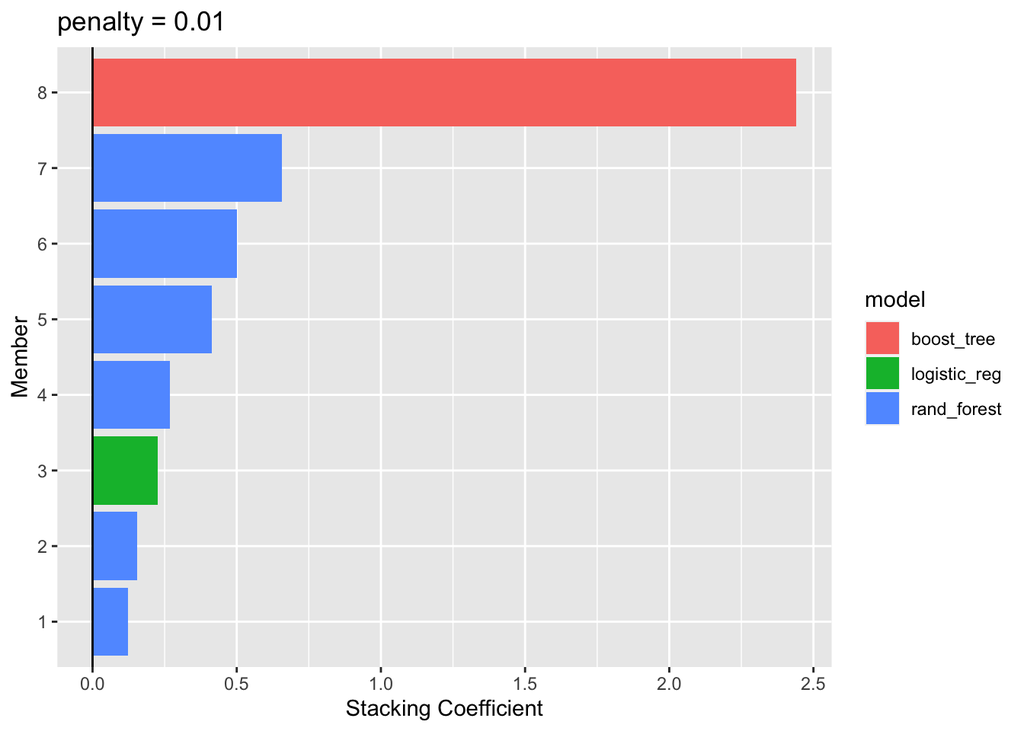

```r
autoplot(mimiciv_icu_cohort_model_st, type = "weights")
```

**Performance and interpretability**

The stacking model has the best performance in terms of accuracy and AUC, but is difficult to interpret. In contrast, each model used in the stacking model is easier to interpret, but does not have good performance in terms of accuracy and AUC. As for the individual models, the random forest and xgboost models have better performance than logistic regression, but are harder to interpret due to complexity and non-linearity. The logistic regression model has the worst performance, but is interpretable due to its simplicity and linearity.

```r
mimiciv_icu_cohort_pred <-
  mimiciv_icu_cohort_test |>
  select(los_long) |>
  bind_cols(
    predict(
      mimiciv_icu_cohort_model_st,
      mimiciv_icu_cohort_test,
      type = "class",
      members = TRUE))
```

```r
map(
  colnames(mimiciv_icu_cohort_pred),
  ~ mean(mimiciv_icu_cohort_pred$los_long == pull(mimiciv_icu_cohort_pred, .x))
  ) |>
  set_names(colnames(mimiciv_icu_cohort_pred)) |>
  as_tibble() |>
  pivot_longer(c(everything(), - los_long))
```

```
# A tibble: 9 × 3
  los_long name                       value
     <dbl> <chr>                      <dbl>
1        1 .pred_class                0.595
2        1 .pred_class_logit_res_1_01 0.572
3        1 .pred_class_rf_res_1_1     0.566
4        1 .pred_class_rf_res_1_4     0.576
5        1 .pred_class_rf_res_1_5     0.560
6        1 .pred_class_rf_res_1_6     0.565
7        1 .pred_class_rf_res_1_7     0.573
8        1 .pred_class_rf_res_1_8     0.575
9        1 .pred_class_gb_res_1_4     0.593
```